# R Notebook

### third predictor

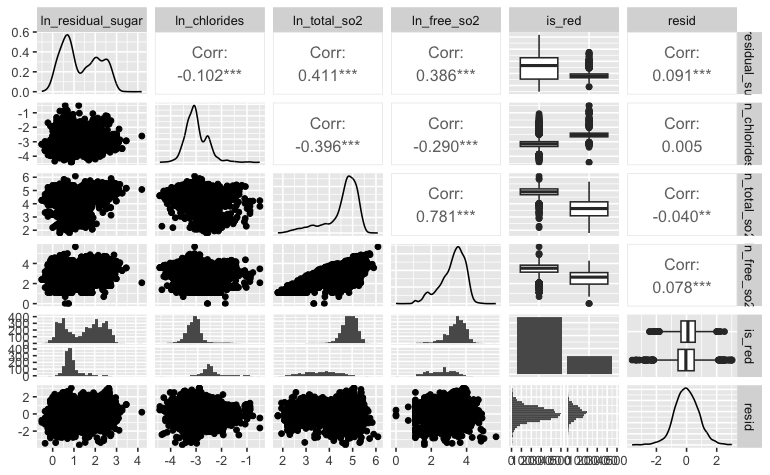

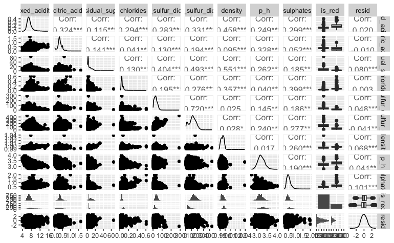

All correlations of remaining variables pretty weak.

But we see that wine_type, has a particular influence on some of the variables. And also seems to have some effect on the remaining residuals:

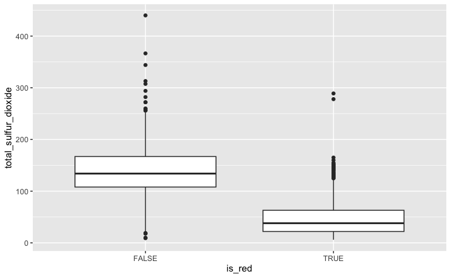

I add is_red (wine type) as variable and see if this improved the model, and if this is justified with an anova

**third predictor**

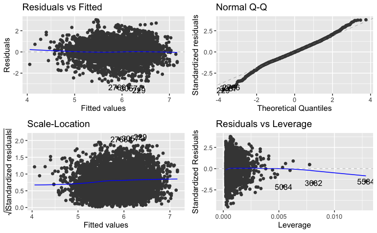

```r
summary(model_3)
```

```
Call:
lm(formula = quality ~ alcohol + volatile_acidity + is_red, data = wine_total)

Residuals:
    Min      1Q  Median      3Q     Max
-3.5969 -0.5211 -0.0099  0.5105  3.0303

Coefficients:
                  Estimate Std. Error t value Pr(>|t|)
(Intercept)       2.897190   0.096546  30.008  < 2e-16 ***
alcohol           0.330220   0.008787  37.579  < 2e-16 ***
volatile_acidity -1.682835   0.083724 -20.100  < 2e-16 ***
is_redTRUE        0.215172   0.032124   6.698 2.31e-11 ***
---
Signif. codes:  0 ‘***’ 0.001 ‘**’ 0.01 ‘*’ 0.05 ‘.’ 0.1 ‘ ’ 1

Residual standard error: 0.8006 on 5845 degrees of freedom
Multiple R-squared:  0.2502,    Adjusted R-squared:  0.2498
F-statistic: 650.1 on 3 and 5845 DF,  p-value: < 2.2e-16
```

Let’s check with an anova if its statistically justified to add is_red

```r
anova(model_2, model_3)
```

```
Analysis of Variance Table

Model 1: quality ~ alcohol + volatile_acidity
Model 2: quality ~ alcohol + volatile_acidity + is_red
  Res.Df    RSS Df Sum of Sq      F    Pr(>F)
1   5846 3775.2
2   5845 3746.4  1    28.758 44.867 2.306e-11 ***
---
Signif. codes:  0 ‘***’ 0.001 ‘**’ 0.01 ‘*’ 0.05 ‘.’ 0.1 ‘ ’ 1
```

yes, adding is_red is significant so let’s leave it.

**explore if fourth predictor makes sense**

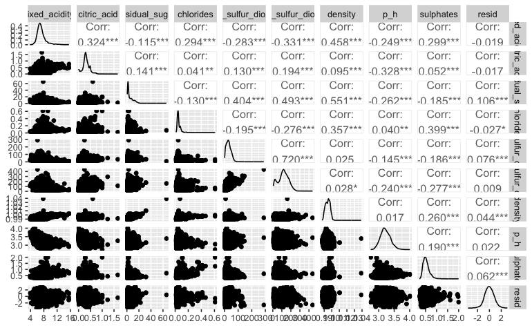

all correlations weak, only residual_sugar is highest with 0.1. Not convincingly high, so let’s check if adding interactions make sense.

### check for interactions

I assume that wine type (is_red) potentially can have a strong interaction with the variables:

```r
# alcohol and wine type
wine_total %>%
  ggplot(aes(x = alcohol, y = quality, colour = is_red)) +
  geom_point() +
  geom_smooth(method = "lm", se = FALSE)
# do not see an interaction here

quality ~ alcohol + volatile_acidity + is_red, wine_total
```

```r
# volatile_acidity and wine type
wine_total %>%
  ggplot(aes(x = volatile_acidity, y = quality, colour = is_red)) +
  geom_point() +
  geom_smooth(method = "lm", se = FALSE)
# do not see an interaction here
```

```r
# winte_type and quality:
wine_total %>%
  ggplot(aes(x = is_red, y = quality, colour = is_red)) +
  geom_boxplot()
```

[figure not shown]

### check AIC : BIC

```r
BIC(model_3)
```

```
[1] 14036.59
```

### check best model on test dataset!

```r
# first combine both red and white wine test datasets

test_white_2 <- test_white %>%
  mutate(is_red = FALSE) %>%
  select(-wine_id)

test_red_2 <- test_red %>%
  mutate(is_red = TRUE) %>%
  select(-wine_id)


wine_test_total <-
  bind_rows(test_white_2, test_red_2) %>%
  select(-region)
```

Now add predictions, based on our model (e.g. to compare model_2 and model_3) and calculate mean squared error. To see which model is best.

```r
# model_2 vs model_3

predictions_test_mod2 <- wine_test_total %>%
  add_predictions(model_2) %>%
  select(quality, pred)

predictions_test_mod3 <- wine_test_total %>%
  add_predictions(model_3) %>%
  select(quality, pred)

#calculate mean squared error for both:
#model_2
mse_model2 <- mean((predictions_test_mod2$pred - wine_test_total$quality)**2)

#model_3
mse_model3 <- mean((predictions_test_mod3$pred - wine_test_total$quality)**2)

#result
mse_model2
# 0.6965714
mse_model3
# 0.6943345
```

A tiny difference, but model_3 is also again better in predicting using the test data set.

```r
mse_train_model3
```

```
[1] 0.6405271
```

Yep, as expected. MSE is slightly smaller for the train set and test set.

### Conclusion

The final model in terms of main effects is: quality ~ alcohol + volatile_acidity + is_red

(with is_red, being the wine type: white or red)

### Extra

Just curious what automated model selection would do:

```r
summary(regsubsets_forward)
```

```
Subset selection object
Call: regsubsets.formula(quality ~ ., data = wine_total, nvmax = 6,
    method = "forward")
12 Variables  (and intercept)
                     Forced in Forced out
fixed_acidity            FALSE      FALSE
volatile_acidity         FALSE      FALSE
citric_acid              FALSE      FALSE
residual_sugar           FALSE      FALSE
chlorides                FALSE      FALSE
free_sulfur_dioxide      FALSE      FALSE
total_sulfur_dioxide     FALSE      FALSE
density                  FALSE      FALSE
p_h                      FALSE      FALSE
sulphates                FALSE      FALSE
alcohol                  FALSE      FALSE
is_redTRUE               FALSE      FALSE
1 subsets of each size up to 6
Selection Algorithm: forward
         fixed_acidity volatile_acidity citric_acid residual_sugar chlorides free_sulfur_dioxide total_sulfur_dioxide density p_h sulphates alcohol
1  ( 1 ) " "           " "              " "         " "            " "       " "                 " "                  " "     " " " "       "*"
2  ( 1 ) " "           "*"              " "         " "            " "       " "                 " "                  " "     " " " "       "*"
3  ( 1 ) " "           "*"              " "         " "            " "       " "                 " "                  " "     " " "*"       "*"
4  ( 1 ) " "           "*"              " "         "*"            " "       " "                 " "                  " "     " " "*"       "*"
5  ( 1 ) " "           "*"              " "         "*"            " "       " "                 " "                  " "     " " "*"       "*"
6  ( 1 ) " "           "*"              " "         "*"            " "       " "                 " "                  "*"     " " "*"       "*"
         is_redTRUE
1  ( 1 ) " "
2  ( 1 ) " "
3  ( 1 ) " "
4  ( 1 ) " "
5  ( 1 ) "*"
6  ( 1 ) "*"
```

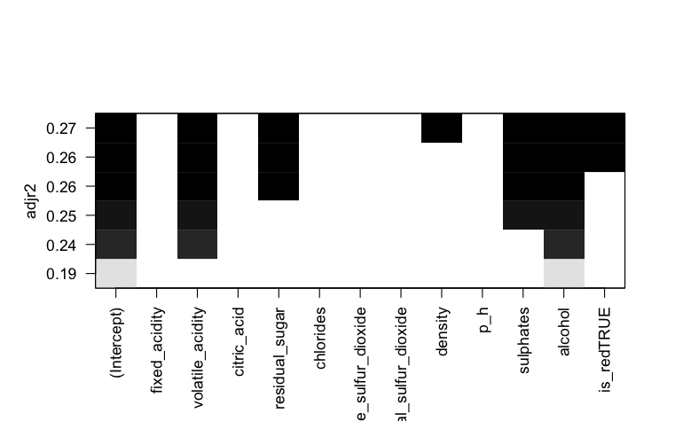

So best 2 predictor model is likely: alcohol, and volatile_acidity 3 predictor model: volatile_acidity, alcohol and sulphates

If I had more time (and energy!) I would now create a model with: volatile_acidity, alcohol and sulphates

And compare with the manual best model. And pick the best performing from these.

========================================================

## Start of homework review Monday 31/07/2023

```r
library(tidyverse)
library(GGally)
library(modelr)
library(skimr)
library(ggfortify)
```

### first step: Approach to measure success and prevent overfitting

1. Goodness of fit measures I use: (adjusted) r-squared, AIC/BIC: parsimonious measures
2. let’s create a Train-Test split with 90:10 ratio
3. k-fold CV? Yes - to prevent over-fitting
4. red/white separately -> lets start with white.

```r
summary(mod3)
```

```
Call:
lm(formula = quality ~ alcohol + log_volatile_acidity, data = train_white_fe)

Residuals:
    Min      1Q  Median      3Q     Max
-3.6138 -0.5473 -0.0129  0.5269  3.2719

Coefficients:
                     Estimate Std. Error t value Pr(>|t|)
(Intercept)           3.12304    0.11290   27.66   <2e-16 ***
alcohol               0.32957    0.01022   32.26   <2e-16 ***
log_volatile_acidity -2.81377    0.16729  -16.82   <2e-16 ***
---
Signif. codes:  0 ‘***’ 0.001 ‘**’ 0.01 ‘*’ 0.05 ‘.’ 0.1 ‘ ’ 1

Residual standard error: 0.8337 on 4406 degrees of freedom
Multiple R-squared:  0.2219,    Adjusted R-squared:  0.2216
F-statistic: 628.3 on 2 and 4406 DF,  p-value: < 2.2e-16
```

```r
# k-fold CV
library(caret)

# you can cross validation a couple of times and compare
# you can do cross validation multiple of times

# In general advice is to first do some more own explorations before starting with
# k-fold cross validation

white_wine_cv_10_fold <- trainControl(method = "cv", # cross-validation
                           number = 10, # 10-fold
                           savePredictions = TRUE) # save all predictions

model_ww10fold <- train(quality ~ .,
               data = white_wine_transform,
               trControl = white_wine_cv_10_fold,
               method = 'lm')
```

```r
# related to how to split your raw data set?

# 70: training
# 20: test: overfitting? Which model does best? Choose best model depending on adjusted-r-squared
# you have used the test data set to make further decissions on which models to pick
# 10: validation set. This is the unbiased dataset for a final view.
# the decision is already made and you use the validation set to do a final validation check.
```